# Predicting customers’ probability of default

#### METHOD 2:Naïve Bayes Classifier

Naive Bayes (NB) is a very simple algorithm based on conditional probability and counting.The Naïve Bayes classifier is a simple probabilistic classifier which is based on Bayes theorem but with strong assumptions regarding independence. It classifies given different instances (object/data) into predefined classes (groups), assuming there is no interdependency of features (class conditional independence).

```r
NBclassfier = naiveBayes(Default ~ ., data=training,metric=metricTarget, trControl=control)
######Predictions on test dataset
pred = predict(NBclassfier, newdata = testing)

confusionMatrix(pred, testing$Default)
```

```
## Confusion Matrix and Statistics
##
##           Reference
## Prediction    0    1
##          0 3023  381
##          1 1644  945
##
##                Accuracy : 0.6621
##                  95% CI : (0.65, 0.6741)
##     No Information Rate : 0.7787
##     P-Value [Acc > NIR] : 1
##
##                   Kappa : 0.2688
##  Mcnemar's Test P-Value : <2e-16
##
##             Sensitivity : 0.6477
##             Specificity : 0.7127
##          Pos Pred Value : 0.8881
##          Neg Pred Value : 0.3650
##              Prevalence : 0.7787
##          Detection Rate : 0.5044
##    Detection Prevalence : 0.5680
##       Balanced Accuracy : 0.6802
##
##        'Positive' Class : 0
##
```

#### METHOD 3: Stochastic Gradient Boosting

Gradient boosting is a machine learning technique for regression and classification problems, which produces a prediction model in the form of an ensemble of weak prediction models, typically decision trees. Boosting is an ensemble technique that attempts to create a strong classifier from a number of weak classifiers. This model builds trees one at a time, where each new tree helps to correct errors made by previously trained tree.The idea of boosting is to train weak learners sequentially, each trying to correct its predecessor.

```r
# METHOD 3: Stochastic Gradient Boosting
GBM.model = train(Default~., data=training, method="gbm", metric=metricTarget, trControl=control)
######Predictions on test dataset
gbm.predictions = predict(GBM.model, newdata=testing)
confusionMatrix(gbm.predictions, testing$Default)
```

```
## Confusion Matrix and Statistics
##
##           Reference
## Prediction    0    1
##          0 4435  854
##          1  232  472
##
##                Accuracy : 0.8188
##                  95% CI : (0.8088, 0.8285)
##     No Information Rate : 0.7787
##     P-Value [Acc > NIR] : 1.205e-14
##
##                   Kappa : 0.368
##  Mcnemar's Test P-Value : < 2.2e-16
##
##             Sensitivity : 0.9503
##             Specificity : 0.3560
##          Pos Pred Value : 0.8385
##          Neg Pred Value : 0.6705
##              Prevalence : 0.7787
##          Detection Rate : 0.7400
##    Detection Prevalence : 0.8825
##       Balanced Accuracy : 0.6531
##
##        'Positive' Class : 0
##
```

#### METHOD 4:Linear Discriminant Analysis

Linear Discriminant Analysis is a supervised classification technique which takes labels into consideration. The goal of Linear Discriminant Analysis is to project the features in higher dimension space onto a lower dimensional space.

```r
# # METHOD 4:Linear Discriminant Analysis with Jacknifed Prediction
# Fit the model
LDA.model = train(Default~., data=training, method="lda", metric=metricTarget, trControl=control)
# Make predictions
lda.predictions = LDA.model %>% predict(testing)
# Model accuracy
confusionMatrix(testing$Default, lda.predictions)
```

```
## Confusion Matrix and Statistics
##
##           Reference
## Prediction    0    1
##          0 4423  244
##          1  842  484
##
##                Accuracy : 0.8188
##                  95% CI : (0.8088, 0.8285)
##     No Information Rate : 0.8785
##     P-Value [Acc > NIR] : 1
##
##                   Kappa : 0.3729
##  Mcnemar's Test P-Value : <2e-16
##
##             Sensitivity : 0.8401
##             Specificity : 0.6648
##          Pos Pred Value : 0.9477
##          Neg Pred Value : 0.3650
##              Prevalence : 0.8785
##          Detection Rate : 0.7380
##    Detection Prevalence : 0.7787
##       Balanced Accuracy : 0.7525
##
##        'Positive' Class : 0
##
```

#### METHOD 5:Decision Tree:

Decision Trees are broadly used supervised models for classification and regression tasks. A decision tree can be used to visually and explicitly represent decisions and decision making.

```r
# # METHOD 5:Decision Tree:
# Fit the model
model2 = train(Default~., data = training, method = "rpart",metric=metricTarget, trControl=control)
# Make predictions
dt.predictions =model2 %>% predict(testing)

# Model confusion matrix
confusionMatrix(testing$Default, dt.predictions)
```

```
## Confusion Matrix and Statistics
##
##           Reference
## Prediction    0    1
##          0 4491  176
##          1  938  388
##
##                Accuracy : 0.8141
##                  95% CI : (0.804, 0.8239)
##     No Information Rate : 0.9059
##     P-Value [Acc > NIR] : 1
##
##                   Kappa : 0.3209
##  Mcnemar's Test P-Value : <2e-16
##
##             Sensitivity : 0.8272
##             Specificity : 0.6879
##          Pos Pred Value : 0.9623
##          Neg Pred Value : 0.2926
##              Prevalence : 0.9059
##          Detection Rate : 0.7494
##    Detection Prevalence : 0.7787
##       Balanced Accuracy : 0.7576
##
##        'Positive' Class : 0
##
```

```r
### Compare the predictive models
preds_list =resamples(list( LDA=LDA.model, DT=model2,  GLM=fit.glm, GBM=GBM.model))
summary(preds_list)
```

```
##
## Call:
## summary.resamples(object = preds_list)
##
## Models: LDA, DT, GLM, GBM
## Number of resamples: 30
##
## Accuracy
##          Min.   1st Qu.    Median      Mean   3rd Qu.      Max. NA's
## LDA 0.8105966 0.8157734 0.8214807 0.8207545 0.8250626 0.8326377    6
## DT  0.8051731 0.8150350 0.8187696 0.8181354 0.8231122 0.8260325    0
## GLM 0.8072591 0.8180017 0.8206839 0.8211248 0.8255293 0.8351419    0
## GBM 0.8110138 0.8174330 0.8211009 0.8210552 0.8241552 0.8314560    0
##
## Kappa
##          Min.   1st Qu.    Median      Mean   3rd Qu.      Max. NA's
## LDA 0.3407064 0.3626307 0.3832210 0.3827530 0.4015317 0.4317238    6
## DT  0.2951867 0.3282778 0.3465284 0.3419459 0.3570009 0.3736862    0
## GLM 0.3323289 0.3572287 0.3712650 0.3745893 0.3958928 0.4219559    0
## GBM 0.3414280 0.3690794 0.3801604 0.3794854 0.3868858 0.4222128    0
```

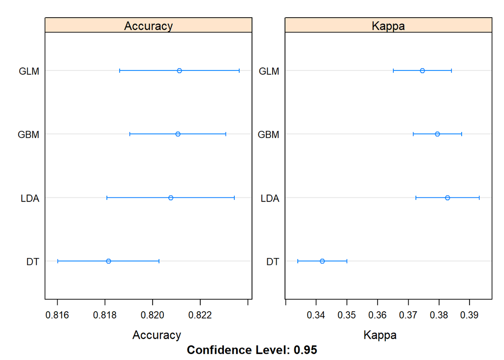

```r
# dot plots of accuracy
scales = list(x=list(relation="free"), y=list(relation="free"))
dotplot(preds_list, scales=scales)
```

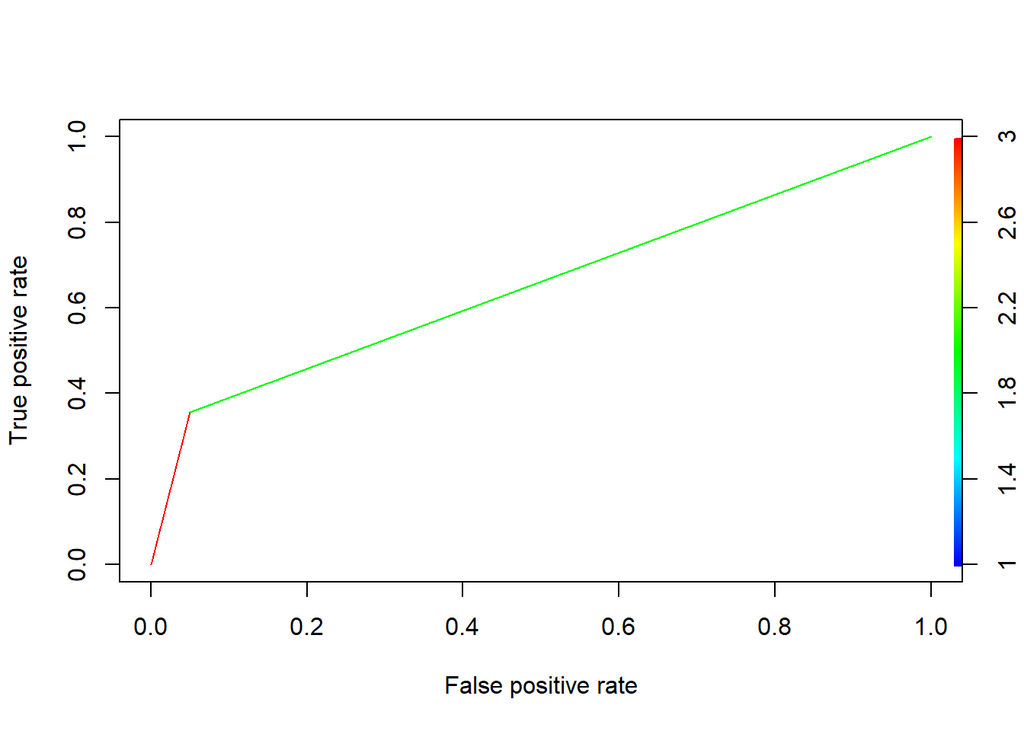

```r
pred = prediction(as.numeric(gbm.predictions), as.numeric(testing$Default))
perf = performance(pred, measure = "tpr", x.measure = "fpr")
plot(perf, colorize=TRUE)
```

```r
auc = performance(pred, measure = "auc")
auc = auc@y.values[[1]]
auc
```

```
## [1] 0.6531235
```

## 5: Business insights and segmentation of customers

```r
head(data_c)
```

```
##   Credit_Amount Gender Education Marital_status Age RepayS_0 RepayS_1
## 1         20000      2         2              1  24        2        2
## 2        120000      2         2              2  26       -1        2
## 3         90000      2         2              2  34        0        0
## 4         50000      2         2              1  37        0        0
## 5         50000      1         2              1  57       -1        0
## 6         50000      1         1              2  37        0        0
##   RepayS_2 RepayS_3 RepayS_4 RepayS_5 BillS_0 BillS_1 BillS_2 BillS_3
## 1       -1       -1       -2       -2    3913    3102     689       0
## 2        0        0        0        2    2682    1725    2682    3272
## 3        0        0        0        0   29239   14027   13559   14331
## 4        0        0        0        0   46990   48233   49291   28314
## 5       -1        0        0        0    8617    5670   35835   20940
## 6        0        0        0        0   64400   57069   57608   19394
##   BillS_4 BillS_5 PrePay_0 PrePay_1 PrePay_2 PrePay_3 PrePay_4 PrePay_5
## 1       0       0        0      689        0        0        0        0
## 2    3455    3261        0     1000     1000     1000        0     2000
## 3   14948   15549     1518     1500     1000     1000     1000     5000
## 4   28959   29547     2000     2019     1200     1100     1069     1000
## 5   19146   19131     2000    36681    10000     9000      689      679
## 6   19619   20024     2500     1815      657     1000     1000      800
##   Default
## 1       1
## 2       1
## 3       0
## 4       0
## 5       0
## 6       0
```

```r
# Running or cumulative sum of bill amount - payment amount for each individual
data_c$Amount_owed = data_c$BillS_0 + data_c$BillS_1 + data_c$BillS_2 + data_c$BillS_3 + data_c$BillS_4 + data_c$BillS_5 - data_c$PrePay_0 - data_c$PrePay_1 - data_c$PrePay_2 - data_c$PrePay_3 - data_c$PrePay_4 - credit$PrePay_5
#Mean value of AMT_OWED over a 6 month period
data_c$AVG_6MTH_BAL = data_c$Amount_owed/6

#Average 6 month balance divided by the individual’s credit limit
data_c$Bal_Lim_Ratio= round(data_c$AVG_6MTH_BAL/data_c$Credit_Amount,3)
data_c = data_c[, -c(12:23)] # delete columns 5 through 7
head(data_c)
```

```
##   Credit_Amount Gender Education Marital_status Age RepayS_0 RepayS_1
## 1         20000      2         2              1  24        2        2
## 2        120000      2         2              2  26       -1        2
## 3         90000      2         2              2  34        0        0
## 4         50000      2         2              1  37        0        0
## 5         50000      1         2              1  57       -1        0
## 6         50000      1         1              2  37        0        0
##   RepayS_2 RepayS_3 RepayS_4 RepayS_5 Default Amount_owed AVG_6MTH_BAL
## 1       -1       -1       -2       -2       1        7015     1169.167
## 2        0        0        0        2       1       12077     2012.833
## 3        0        0        0        0       0       90635    15105.833
## 4        0        0        0        0       0      222946    37157.667
## 5       -1        0        0        0       0       50290     8381.667
## 6        0        0        0        0       0      230342    38390.333
##   Bal_Lim_Ratio
## 1         0.058
## 2         0.017
## 3         0.168
## 4         0.743
## 5         0.168
## 6         0.768
```

```r
# Customer segmentation
data_c$Default=as.numeric(data_c$Default)
df = scale(data_c)
head(df)
```

```
##      Credit_Amount     Gender  Education Marital_status        Age
## [1,]    -1.1367012  0.8101472  0.1858252      -1.057277 -1.2459991
## [2,]    -0.3659744  0.8101472  0.1858252       0.858543 -1.0290300
## [3,]    -0.5971924  0.8101472  0.1858252       0.858543 -0.1611538
## [4,]    -0.9054832  0.8101472  0.1858252      -1.057277  0.1642998
## [5,]    -0.9054832 -1.2343024  0.1858252      -1.057277  2.3339904
## [6,]    -0.9054832 -1.2343024 -1.0794392       0.858543  0.1642998
##         RepayS_0  RepayS_1   RepayS_2   RepayS_3   RepayS_4   RepayS_5
## [1,]  1.79453395 1.7823185 -0.6966518 -0.6665876 -1.5300205 -1.4860160
## [2,] -0.87497656 1.7823185  0.1388625  0.1887429  0.2349126  1.9922823
## [3,]  0.01486028 0.1117342  0.1388625  0.1887429  0.2349126  0.2531332
## [4,]  0.01486028 0.1117342  0.1388625  0.1887429  0.2349126  0.2531332
## [5,] -0.87497656 0.1117342 -0.6966518  0.1887429  0.2349126  0.2531332
## [6,]  0.01486028 0.1117342  0.1388625  0.1887429  0.2349126  0.2531332
##         Default Amount_owed AVG_6MTH_BAL Bal_Lim_Ratio
## [1,]  1.8763471 -0.63265678  -0.63265678    -0.7922386
## [2,]  1.8763471 -0.61880446  -0.61880446    -0.9121125
## [3,] -0.5329327 -0.40382807  -0.40382807    -0.4706255
## [4,] -0.5329327 -0.04175493  -0.04175493     1.2105336
## [5,] -0.5329327 -0.51423340  -0.51423340    -0.4706255
## [6,] -0.5329327 -0.02151555  -0.02151555     1.2836274
```

```r
#K means clustering
km.res = kmeans(df, 5, nstart = 25)
str(km.res)
```

```
## List of 9
##  $ cluster     : int [1:30000] 2 1 1 2 2 1 4 1 2 5 ...
##  $ centers     : num [1:5, 1:15] -0.371 -0.318 -0.672 0.955 0.494 ...
##   ..- attr(*, "dimnames")=List of 2
##   .. ..$ : chr [1:5] "1" "2" "3" "4" ...
##   .. ..$ : chr [1:15] "Credit_Amount" "Gender" "Education" "Marital_status" ...
##  $ totss       : num 449985
##  $ withinss    : num [1:5] 57954 56053 41424 28384 76022
##  $ tot.withinss: num 259837
##  $ betweenss   : num 190148
##  $ size        : int [1:5] 8171 6801 2993 2747 9288
##  $ iter        : int 5
##  $ ifault      : int 0
##  - attr(*, "class")= chr "kmeans"
```

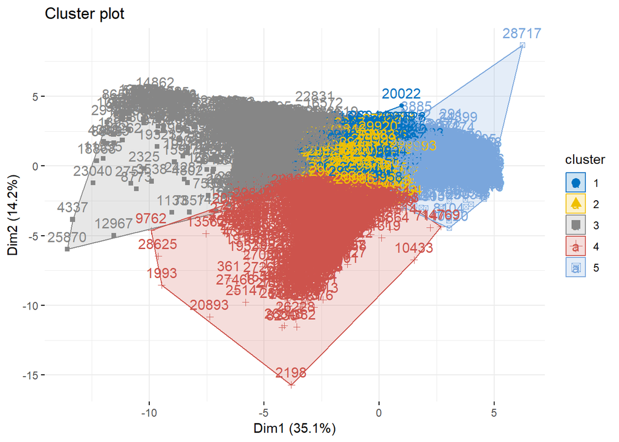

```r
fviz_cluster(km.res, data = df,
             ellipse.type = "convex",
             palette = "jco",
             ggtheme = theme_minimal())
```

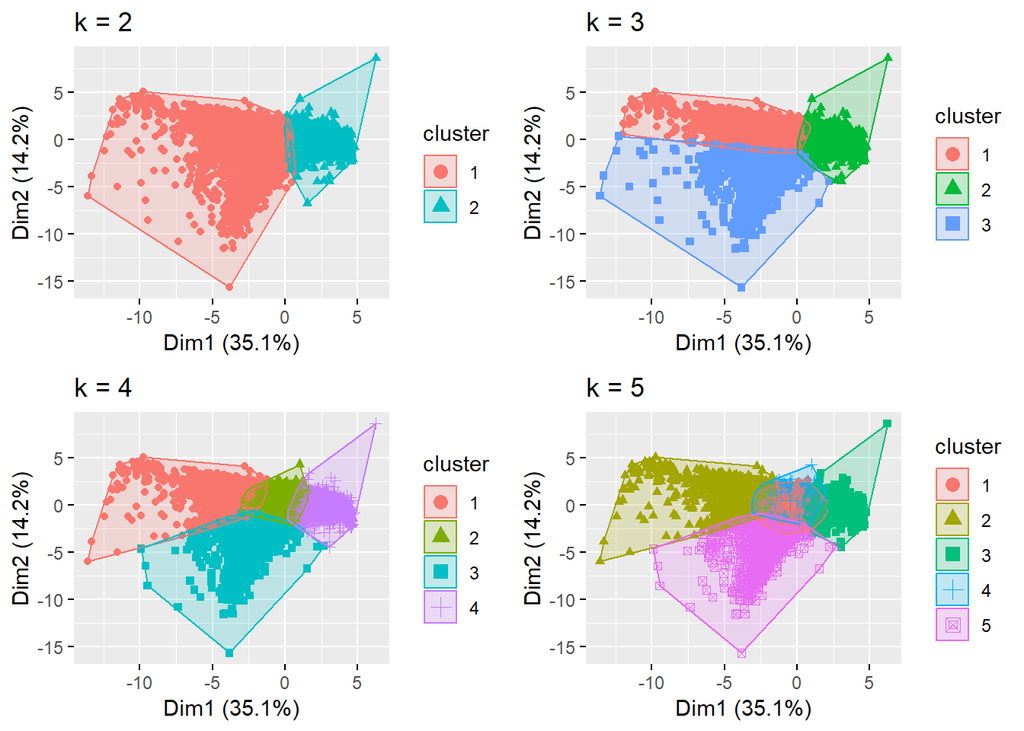

```r
k3 = kmeans(df, centers = 3, nstart = 25)
k4 = kmeans(df, centers = 4, nstart = 25)
k5 = kmeans(df, centers = 5, nstart = 25)
k2 = kmeans(df, centers = 2, nstart = 25)
# plots to compare
p1 = fviz_cluster(k2, geom = "point", data = df) + ggtitle("k = 2")
p2 = fviz_cluster(k3, geom = "point",  data = df) + ggtitle("k = 3")
p3 = fviz_cluster(k4, geom = "point",  data = df) + ggtitle("k = 4")
p4 = fviz_cluster(k5, geom = "point",  data = df) + ggtitle("k = 5")

grid.arrange(p1, p2, p3, p4, nrow = 2)
```

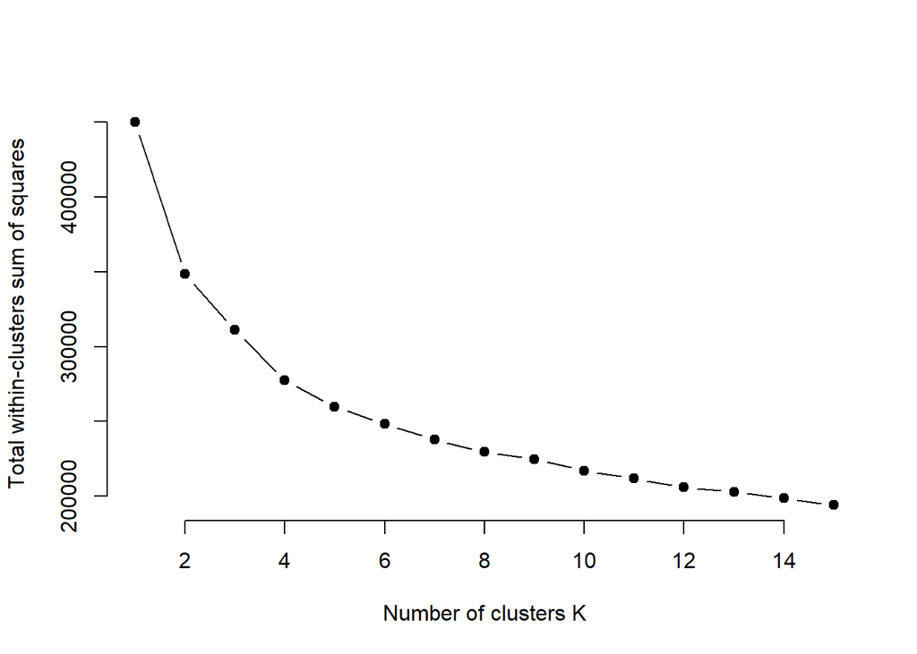

```r
#using elbow method to determine the number of clusters
set.seed(123)

# function to compute total within-cluster sum of square
wss = function(k) {
  kmeans(df, k, nstart = 10 )$tot.withinss
}

# Compute and plot wss for k = 1 to k = 15
k.values = 1:15

# extract wss for 2-15 clusters
wss_values = map_dbl(k.values, wss)
plot(k.values, wss_values,
       type="b", pch = 19, frame = FALSE,
       xlab="Number of clusters K",
       ylab="Total within-clusters sum of squares")
```

```r
# Compute k-means clustering with k = 4
set.seed(123)
final = kmeans(df, 4, nstart = 25)
```

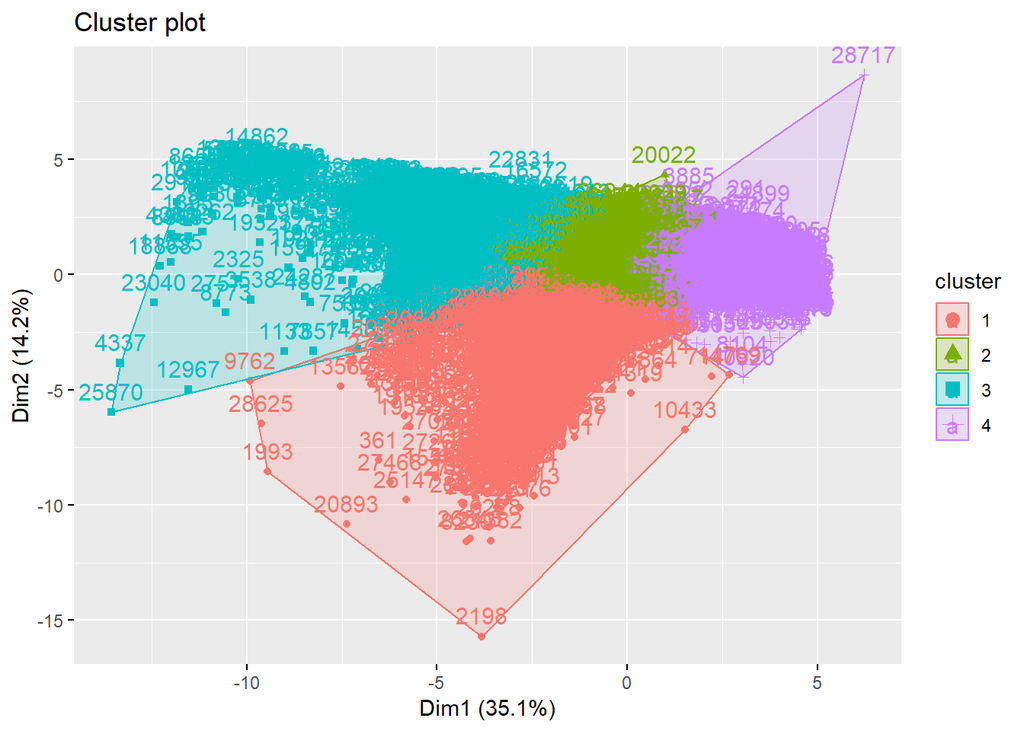

```r
fviz_cluster(final, data = df)
```

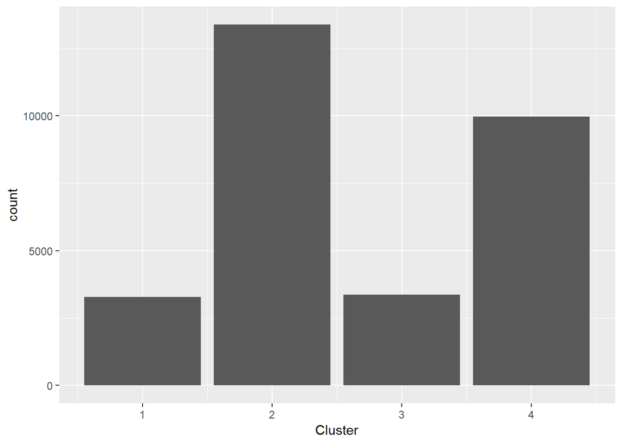

```r
new = data_c %>%
  mutate(Cluster = final$cluster)
new$Cluster=as.numeric(new$Cluster)

ggplot(new, aes(x=Cluster, fill=Gender)) + geom_bar(position="dodge")
```

```r
cluster1= sqldf("select * from new where Cluster=1")
summary(cluster1)
```

```
##  Credit_Amount         Gender        Education     Marital_status
##  Min.   :  20000   Min.   :1.000   Min.   :1.000   Min.   :1.000
##  1st Qu.: 190000   1st Qu.:1.000   1st Qu.:1.000   1st Qu.:1.000
##  Median : 250000   Median :2.000   Median :2.000   Median :1.000
##  Mean   : 279893   Mean   :1.584   Mean   :1.818   Mean   :1.482
##  3rd Qu.: 350000   3rd Qu.:2.000   3rd Qu.:2.000   3rd Qu.:2.000
##  Max.   :1000000   Max.   :2.000   Max.   :6.000   Max.   :3.000
##       Age           RepayS_0          RepayS_1          RepayS_2
##  Min.   :22.00   Min.   :-2.0000   Min.   :-2.0000   Min.   :-2.0000
##  1st Qu.:30.00   1st Qu.: 0.0000   1st Qu.: 0.0000   1st Qu.: 0.0000
##  Median :36.00   Median : 0.0000   Median : 0.0000   Median : 0.0000
##  Mean   :37.52   Mean   : 0.1927   Mean   : 0.1598   Mean   : 0.1235
##  3rd Qu.:43.00   3rd Qu.: 0.0000   3rd Qu.: 0.0000   3rd Qu.: 0.0000
##  Max.   :79.00   Max.   : 5.0000   Max.   : 4.0000   Max.   : 4.0000
##     RepayS_3           RepayS_4           RepayS_5           Default
##  Min.   :-2.00000   Min.   :-2.00000   Min.   :-2.00000   Min.   :0.0000
##  1st Qu.: 0.00000   1st Qu.: 0.00000   1st Qu.: 0.00000   1st Qu.:0.0000
##  Median : 0.00000   Median : 0.00000   Median : 0.00000   Median :0.0000
##  Mean   : 0.08966   Mean   : 0.06984   Mean   : 0.08265   Mean   :0.1568
##  3rd Qu.: 0.00000   3rd Qu.: 0.00000   3rd Qu.: 0.00000   3rd Qu.:0.0000
##  Max.   : 7.00000   Max.   : 6.00000   Max.   : 6.00000   Max.   :1.0000
##   Amount_owed       AVG_6MTH_BAL    Bal_Lim_Ratio       Cluster
##  Min.   : 343063   Min.   : 57177   Min.   :0.0810   Min.   :1
##  1st Qu.: 747598   1st Qu.:124600   1st Qu.:0.5330   1st Qu.:1
##  Median : 928948   Median :154825   Median :0.7110   Median :1
##  Mean   :1062446   Mean   :177074   Mean   :0.6888   Mean   :1
##  3rd Qu.:1222912   3rd Qu.:203819   3rd Qu.:0.8510   3rd Qu.:1
##  Max.   :4161784   Max.   :693631   Max.   :5.2150   Max.   :1
```

Group 2 – Young university graduates low default customers • Mostly single female customers with average age of 34 years • Pay their credit liability when due and have a low default rate • Customers in this segment have a university degree and higher degrees

```r
cluster2= sqldf("select * from new where Cluster=2")
summary(cluster2)
```

```
##  Credit_Amount        Gender        Education     Marital_status
##  Min.   : 10000   Min.   :1.000   Min.   :0.000   Min.   :0.000
##  1st Qu.: 50000   1st Qu.:1.000   1st Qu.:1.000   1st Qu.:1.000
##  Median : 80000   Median :2.000   Median :2.000   Median :2.000
##  Mean   :116079   Mean   :1.589   Mean   :1.974   Mean   :1.621
##  3rd Qu.:160000   3rd Qu.:2.000   3rd Qu.:2.000   3rd Qu.:2.000
##  Max.   :640000   Max.   :2.000   Max.   :6.000   Max.   :3.000
##       Age           RepayS_0           RepayS_1           RepayS_2
##  Min.   :21.00   Min.   :-2.00000   Min.   :-2.00000   Min.   :-2.0000
##  1st Qu.:27.00   1st Qu.: 0.00000   1st Qu.: 0.00000   1st Qu.: 0.0000
##  Median :32.00   Median : 0.00000   Median : 0.00000   Median : 0.0000
##  Mean   :34.18   Mean   : 0.09566   Mean   : 0.08998   Mean   : 0.1039
##  3rd Qu.:40.00   3rd Qu.: 0.00000   3rd Qu.: 0.00000   3rd Qu.: 0.0000
##  Max.   :71.00   Max.   : 3.00000   Max.   : 3.00000   Max.   : 3.0000
##     RepayS_3           RepayS_4           RepayS_5          Default
##  Min.   :-2.00000   Min.   :-2.00000   Min.   :-2.0000   Min.   :0.0000
##  1st Qu.: 0.00000   1st Qu.: 0.00000   1st Qu.: 0.0000   1st Qu.:0.0000
##  Median : 0.00000   Median : 0.00000   Median : 0.0000   Median :0.0000
##  Mean   : 0.04222   Mean   :-0.02137   Mean   :-0.0488   Mean   :0.1568
##  3rd Qu.: 0.00000   3rd Qu.: 0.00000   3rd Qu.: 0.0000   3rd Qu.:0.0000
##  Max.   : 3.00000   Max.   : 4.00000   Max.   : 6.0000   Max.   :1.0000
##   Amount_owed       AVG_6MTH_BAL    Bal_Lim_Ratio       Cluster
##  Min.   :-283136   Min.   :-47189   Min.   :-2.354   Min.   :2
##  1st Qu.:  73407   1st Qu.: 12234   1st Qu.: 0.145   1st Qu.:2
##  Median : 162443   Median : 27074   Median : 0.391   Median :2
##  Mean   : 201058   Mean   : 33510   Mean   : 0.413   Mean   :2
##  3rd Qu.: 295223   3rd Qu.: 49204   3rd Qu.: 0.658   3rd Qu.:2
##  Max.   : 685095   Max.   :114183   Max.   : 2.590   Max.   :2
```

Group 3 – Late paying high default customers • Single and married customers with average age of 35 years •Highest percentage of defaulters above 70% • Have an average of 2 months payment delay and have a high default rate

```r
cluster3= sqldf("select * from new where Cluster=3")
summary(cluster3)
```

```
##  Credit_Amount        Gender        Education     Marital_status
##  Min.   : 10000   Min.   :1.000   Min.   :1.000   Min.   :0.000
##  1st Qu.: 30000   1st Qu.:1.000   1st Qu.:2.000   1st Qu.:1.000
##  Median : 50000   Median :2.000   Median :2.000   Median :2.000
##  Mean   : 79269   Mean   :1.545   Mean   :1.994   Mean   :1.531
##  3rd Qu.:100000   3rd Qu.:2.000   3rd Qu.:2.000   3rd Qu.:2.000
##  Max.   :510000   Max.   :2.000   Max.   :6.000   Max.   :3.000
##       Age           RepayS_0         RepayS_1         RepayS_2
##  Min.   :21.00   Min.   :-2.000   Min.   :-1.000   Min.   :-2.000
##  1st Qu.:27.00   1st Qu.: 1.000   1st Qu.: 2.000   1st Qu.: 2.000
##  Median :33.00   Median : 2.000   Median : 2.000   Median : 2.000
##  Mean   :35.13   Mean   : 1.654   Mean   : 1.869   Mean   : 1.803
##  3rd Qu.:42.00   3rd Qu.: 2.000   3rd Qu.: 2.000   3rd Qu.: 2.000
##  Max.   :73.00   Max.   : 8.000   Max.   : 8.000   Max.   : 8.000
##     RepayS_3         RepayS_4         RepayS_5         Default
##  Min.   :-2.000   Min.   :-2.000   Min.   :-2.000   Min.   :0.0000
##  1st Qu.: 0.000   1st Qu.: 0.000   1st Qu.: 0.000   1st Qu.:0.0000
##  Median : 2.000   Median : 2.000   Median : 2.000   Median :1.0000
##  Mean   : 1.674   Mean   : 1.491   Mean   : 1.343   Mean   :0.7157
##  3rd Qu.: 2.000   3rd Qu.: 2.000   3rd Qu.: 2.000   3rd Qu.:1.0000
##  Max.   : 8.000   Max.   : 8.000   Max.   : 8.000   Max.   :1.0000
##   Amount_owed       AVG_6MTH_BAL    Bal_Lim_Ratio        Cluster
##  Min.   :-301688   Min.   :-50281   Min.   :-1.1350   Min.   :3
##  1st Qu.:  88797   1st Qu.: 14800   1st Qu.: 0.3713   1st Qu.:3
##  Median : 166394   Median : 27732   Median : 0.6400   Median :3
##  Mean   : 249917   Mean   : 41653   Mean   : 0.5872   Mean   :3
##  3rd Qu.: 336970   3rd Qu.: 56162   3rd Qu.: 0.8350   3rd Qu.:3
##  Max.   :2741745   Max.   :456958   Max.   : 2.5580   Max.   :3
```

```r
cluster4= sqldf("select * from new where Cluster=4")
summary(cluster4)
```

```
##  Credit_Amount        Gender       Education     Marital_status
##  Min.   : 10000   Min.   :1.00   Min.   :0.000   Min.   :0.00
##  1st Qu.:140000   1st Qu.:1.00   1st Qu.:1.000   1st Qu.:1.00
##  Median :210000   Median :2.00   Median :1.000   Median :1.00
##  Mean   :229265   Mean   :1.65   Mean   :1.655   Mean   :1.49
##  3rd Qu.:310000   3rd Qu.:2.00   3rd Qu.:2.000   3rd Qu.:2.00
##  Max.   :800000   Max.   :2.00   Max.   :6.000   Max.   :3.00
##       Age           RepayS_0       RepayS_1         RepayS_2
##  Min.   :21.00   Min.   :-2.0   Min.   :-2.000   Min.   :-2.000
##  1st Qu.:30.00   1st Qu.:-2.0   1st Qu.:-2.000   1st Qu.:-2.000
##  Median :35.00   Median :-1.0   Median :-1.000   Median :-1.000
##  Mean   :36.69   Mean   :-0.8   Mean   :-1.206   Mean   :-1.288
##  3rd Qu.:42.00   3rd Qu.: 0.0   3rd Qu.:-1.000   3rd Qu.:-1.000
##  Max.   :75.00   Max.   : 2.0   Max.   : 2.000   Max.   : 2.000
##     RepayS_3         RepayS_4         RepayS_5        Default
##  Min.   :-2.000   Min.   :-2.000   Min.   :-2.00   Min.   :0.0000
##  1st Qu.:-2.000   1st Qu.:-2.000   1st Qu.:-2.00   1st Qu.:0.0000
##  Median :-1.000   Median :-1.000   Median :-1.00   Median :0.0000
##  Mean   :-1.315   Mean   :-1.298   Mean   :-1.29   Mean   :0.1619
##  3rd Qu.:-1.000   3rd Qu.:-1.000   3rd Qu.:-1.00   3rd Qu.:0.0000
##  Max.   : 2.000   Max.   : 2.000   Max.   : 3.00   Max.   :1.0000
##   Amount_owed        AVG_6MTH_BAL       Bal_Lim_Ratio         Cluster
##  Min.   :-2527301   Min.   :-421216.8   Min.   :-1.51700   Min.   :4
##  1st Qu.:   -2000   1st Qu.:   -333.3   1st Qu.:-0.00200   1st Qu.:4
##  Median :     499   Median :     83.2   Median : 0.00000   Median :4
##  Mean   :   13114   Mean   :   2185.6   Mean   : 0.01079   Mean   :4
##  3rd Qu.:   10086   3rd Qu.:   1680.9   3rd Qu.: 0.00800   3rd Qu.:4
##  Max.   :  958802   Max.   : 159800.3   Max.   : 1.21400   Max.   :4
```

```r
seq(20,80, by =10)
```

```
## [1] 20 30 40 50 60 70 80
```

```r
new =new %>% mutate(age_cat = cut(Age, breaks = seq(20,80, by =10)))

new =new %>% mutate(credit_lim = cut(Credit_Amount, breaks = seq(1,1000000, by =50000)))
write.csv(new, "segment.csv")
```